# Catherine Penaranda Escobar

# About Me

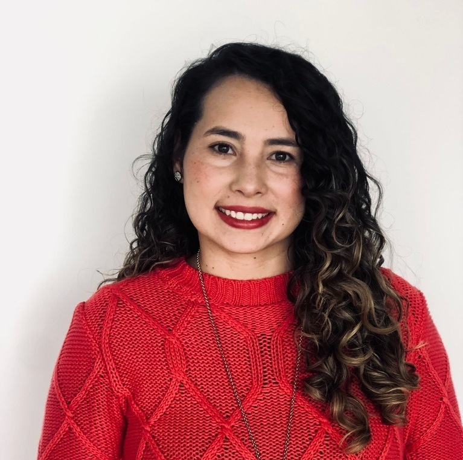

Catherine Penaranda Escobar

I’m **Catherine Penaranda Escobar**, a dedicated and results-oriented Results-driven professional with a background in economics, public policy, and business strategy. Experienced in project management and stakeholder engagement. Skilled in analyzing economic trends, developing strategic policies, and leading cross-functional teams. Currently pursuing an MBA to enhance leadership and financial decision-making skills.

# Education

- **MBA Candidate**, University Canada West, Vancouver, Canada. *(2024 – Present)*
- **Master of Public Policy in Economics**, Universidad del Rosario, Bogota, Colombia. *(2018 – 2021)*
- **Specialist in Public Policy Analysis**, Universidad Nacional de Colombia, Bogota, Colombia. *(2013 – 2014)*
- **Economist**, Escuela Colombiana de Ingeniería “Julio Garavito”, Bogota, Colombia. *(2007 – 2012)*

# Professional Experience

### Project Coordinator

**Colombian Association of Oil and Gas**, Bogota, Colombia.  
*2021 – 2024*

- Developed and implemented social and environmental projects in oil and gas regions.
- Built relationships with stakeholders, government agencies, and private sector partners.
- Managed project timelines, budgets, and risk assessments.

### Specialized Professional

**Ministry of Agriculture and Rural Development**, Bogota, Colombia. *2013 – 2021*

- Designed and monitored public policies for agricultural finance and production chains.
- Conducted economic research and policy assessments to support sustainable development.
- Collaborated with cross-functional teams to implement regulatory frameworks.

# Key Skills

**Hard Skills**

- 🌟 Economic and policy analysis
- 🌟 Business strategy
- 🌟 Project management
- 🌟 Market research and data analysis
- 🌟 Stakeholder engagement
- 🌟 Microsoft Office Suite (Excel, Word, PowerPoint, Outlook)
- 🌟 Canva (Graphic design and presentations)

**Soft Skills**

- 🌟 Leadership and strategic vision
- 🌟 Problem-solving and critical thinking
- 🌟 Communication and negotiation
- 🌟 Adaptability and teamwork
- 🌟 Multicultural awareness

# Contact

📧 **Email:** catapees@gmail.com 🌐 **LinkedIn:** www.linkedin.com/in/catherine-peñaranda-escobar-401b7385  
📍 **Location:** New Westminster, BC, Canada